# Key 11 ANCOVA

## GRADED both lines

1.8 Repeat the plot in 1.6, but now add a line of best fit. Below the plot, say whether or not your answer in 1.7 is supported or if you’ve changed your mind.

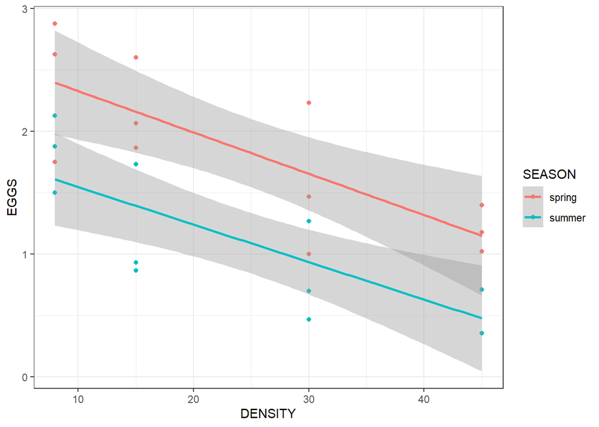

```r
ggplot(limp,
       aes(y = EGGS,
           x = DENSITY,
           color = SEASON)) +
  geom_point() +
  theme_bw() +
  geom_smooth(method = "lm")
```

```r
# There are now two lines. They appear to be parallel (no interaction), but the intercepts seem to be different (Main effect of SEASON)
```

1.9 Let’s check the normality of residuals with a qq-plot. Make the plot in a code chunk, then write your answer below discussing if we meet or fail or assumption.

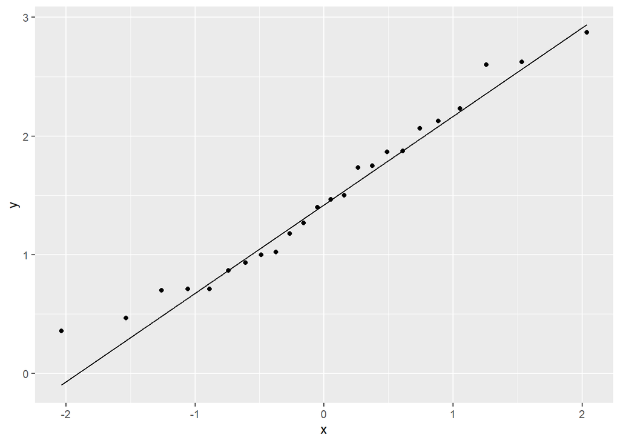

```r
ggplot(limp,
       aes(sample = EGGS)) +
  stat_qq()+
  stat_qq_line()
```

```r
# Like Tony the Tiger says: they're grrrrreat!
# even spread and points are close to the line.
```

1.10 Fit a model using `lm()` for the limpet data, and save it as a new data object. Make sure to include main effects of both explanatory AND the interaction between them.

```r
limp_lm <- lm(EGGS ~ DENSITY * SEASON, data = limp)
```

1.11 Before we look at the model output, let’s make a fitted vs. residual plot to check our assumption of Equal variance of residuals.

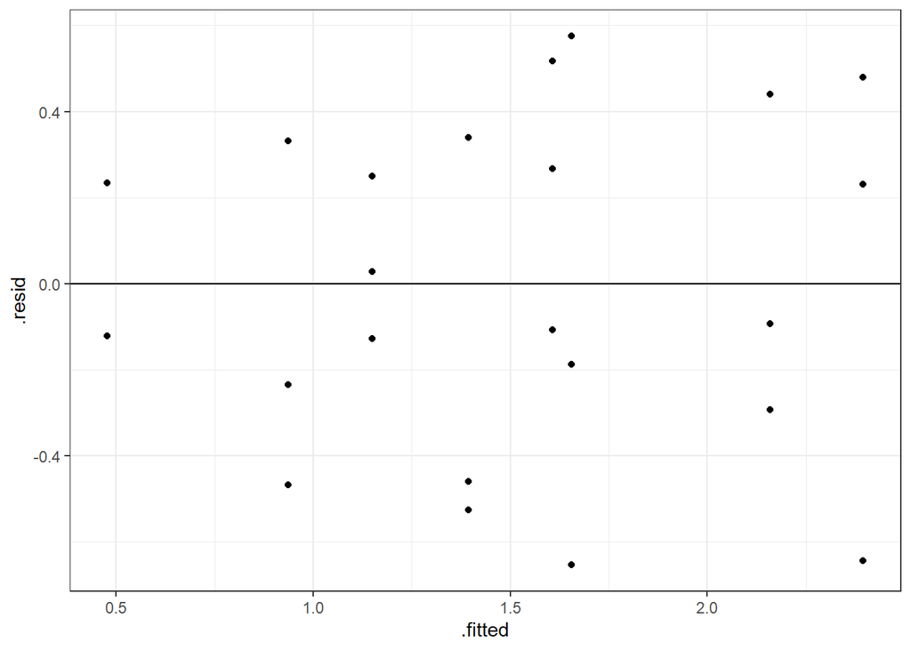

```r
ggplot(limp_lm,
       aes(x = .fitted,
           y = .resid)) +
  geom_point() +
    geom_hline(yintercept = 0) +
  theme_bw()
```

1.12 Interpret the plot made above. Does this model appear to have equal variance in the residuals? Why or why not?

```r
#  the magnitude of the values appears similar (~-.5, .5)
# There does not appear to be an obvious pattern to the residuals, but maybe less variation on the left side of the plot.
```

1.13 Now, use the `anova()` function on your model fit object above to print out an ANOVA table for your linear regression.

```r
anova(limp_lm)
```

```
Analysis of Variance Table

Response: EGGS
               Df Sum Sq Mean Sq F value    Pr(>F)
DENSITY         1 5.0241  5.0241 30.1971 2.226e-05 ***
SEASON          1 3.2502  3.2502 19.5350 0.0002637 ***
DENSITY:SEASON  1 0.0118  0.0118  0.0711 0.7925333
Residuals      20 3.3275  0.1664
---
Signif. codes:  0 '***' 0.001 '**' 0.01 '*' 0.05 '.' 0.1 ' ' 1
```

## GRADED ANOVA interp

1.14 Interpret the ANOVA table for our ANCOVA analysis. Discuss what the predictor variable means, and how that relates to a linear model. Recall which variables were continuous or categorical.  
- HINT: Continuous predictors indicate if there is a relationship (Linear Regression).  
- Categorical predictors indicate if there is a difference in means between groups (different intercepts)

```r
# DENSITY: small p-value which means that there is a relationship between density and egg production

# SEASON: Small p-value means that there is a difference in means between the two groups, or a difference in intercepts.

# DENSITY:SEASON: high p-value means that there is not an interactive effect between density and season. In other words, the effect of one does not depend on another, or the slopes are the same for the two groups.
```

1.15 Print out the `summary()` of the linear model object you created.

```r
summary(limp_lm)
```

```
Call:
lm(formula = EGGS ~ DENSITY * SEASON, data = limp)

Residuals:
     Min       1Q   Median       3Q      Max
-0.65468 -0.25021 -0.03318  0.28335  0.57532

Coefficients:
                      Estimate Std. Error t value Pr(>|t|)
(Intercept)           2.664166   0.234118  11.380 3.45e-10 ***
DENSITY              -0.033650   0.008259  -4.074 0.000591 ***
SEASONsummer         -0.812282   0.331092  -2.453 0.023450 *
DENSITY:SEASONsummer  0.003114   0.011680   0.267 0.792533
---
Signif. codes:  0 '***' 0.001 '**' 0.01 '*' 0.05 '.' 0.1 ' ' 1

Residual standard error: 0.4079 on 20 degrees of freedom
Multiple R-squared:  0.7135,    Adjusted R-squared:  0.6705
F-statistic:  16.6 on 3 and 20 DF,  p-value: 1.186e-05
```

1.16 Describe what each coefficient means. Be sure to specify what group (if necessary) the coefficient refers to.

```r
# Intercept: This is the estimated number of eggs when x (DENSITY) = 0 for the SPRING season

# DENSITY: this coefficient is the estimated change in the number of eggs with every 1-unit increase in our x-variable (DENSITY) for the spring SEASON

# SEASONsummer: this is the estimated difference between the intercepts for spring and summer. The estimated intercept for summer is therefore 2.66 -0.81 = 1.85

#DENSITY:SEASONsummer: this is the estimated difference in slopes between the spring and summer groups. Therefore the estimated slope for summer is: -0.033+0.003 = -0.03 (although the high p-value means that these are not statistically different)
```

1.17 Report the adjusted R-squared value from our model and give an interpretation for what it means.

```r
# adj R^2 = 0.6705
# This means that the model explains ~67%  of the variation in the response variable.
```

## GRADED line equations

1.18 Add the full equation for our linear model.  
- **HINT**: You should have an equation for spring and an equation for summer  
- Look at the previous lecture notes for Quarto if you need a refresher on how to write math equations. - Write the equations as “block” or “display” equations

$$EGGS_{spring} = \beta_0 + \beta_1 * DENSITY$$

$$EGGS_{summer} = (\beta_0+\beta_{0 \Delta}) + (\beta_1 +\beta_{1 \Delta}) * DENSITY$$

```r
# EGGS_spring = 2.66 - 0.034 * DENSITY
# EGGS_summer = (2.66 - 0.81) - (0.034 - 0.003) * DENSITY  = 1.85 - 0.031 * DENSITY
```

## GRADED prediction ribbons

1.19 Calculate the “prediction” interval for this model and make a plot which includes the original data as points, and the prediction interval. The groups should have different colors/fills, and should be facet wrapped so each group appears in its own panel.  
- **HINTS**  
- Make a “new” data frame with predictor variables - use `length.out = 50` for the continuous predictor - use the “new” data to predict y-value with `interval = "predict"`  
- combine the new x and new y data  
- in `ggplot`, use the original data for your points, and the new combined data for your smooth layer  
- Also add a title explaining that it’s a 95% prediction interval

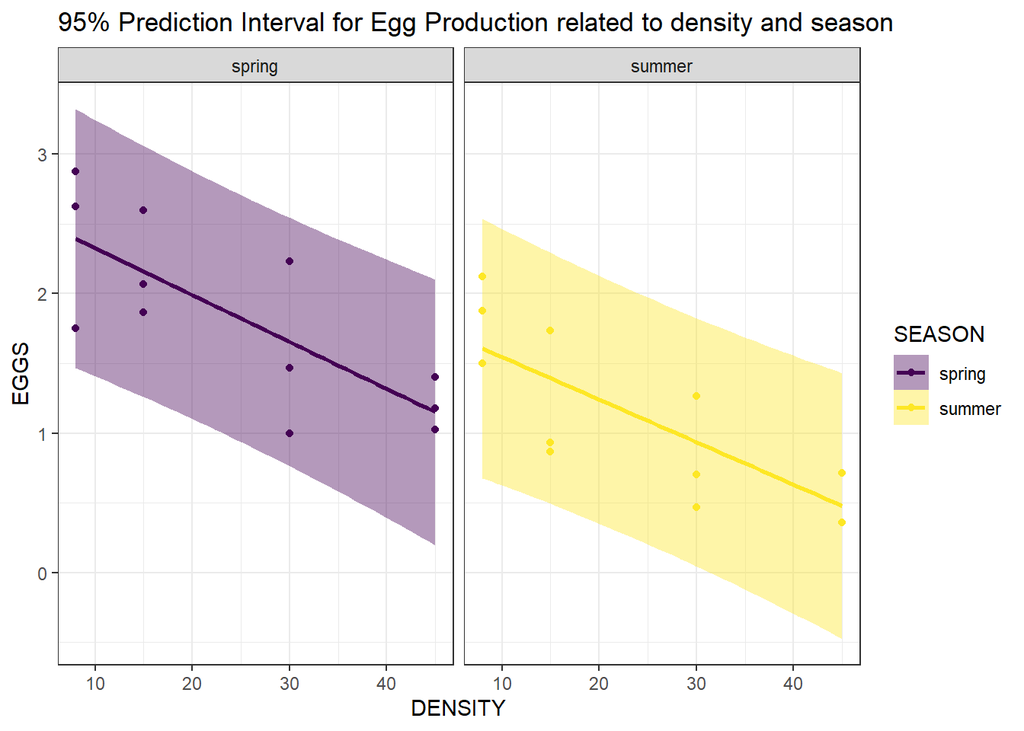

```r
new_x <- expand.grid(
  DENSITY = seq(from = min(limp$DENSITY),
           to = max(limp$DENSITY),
                    length.out = 50),
  SEASON = unique(limp$SEASON))


new_limp <- predict(limp_lm,
                    newdata = new_x,
                    interval = "predict")
new_limp <- data.frame(new_x, new_limp)

ggplot(limp,
       aes(x = DENSITY,
           y = EGGS,
           color = SEASON,
           fill = SEASON)) +
  geom_point() +
  geom_smooth(data = new_limp,
              aes(y = fit,
                  ymin = lwr,
                  ymax = upr),
              stat = "identity") +
  facet_wrap(~SEASON) +
  theme_bw() +
  scale_fill_viridis_d() +
  scale_color_viridis_d() +
  labs(title = "95% Prediction Interval for Egg Production related to density and season")
```